# SCCAF: Single Cell Clustering Assessment Framework

https://github.com/SCCAF/sccaf/blob/develop/notebook/Zeisel_Mouse_Cortex_Demo.ipynb

- Single Cell Clustering Assessment Framework (SCCAF) は、scRNA-seqデータから細胞タイプを自動推定するための新しい手法です。
- 遺伝子発現プロファイルにクラスタリングと機械学習アプローチを再帰的に適用することにより、SCCAFは同時に細胞グループと各グループの特徴遺伝子の重み付けされたリストを同定する。
- 細胞グループは特徴遺伝子によって細胞タイプまたは細胞状態に対応しています。

```python
%pylab inline

import warnings
warnings.filterwarnings("ignore")
from SCCAF import *
import urllib.request
```

```python
urllib.request.urlretrieve("https://drive.google.com/uc?export=download&id=1hprRFkEk8q27kqrt9RLvY6aqu6XWPb2C", 'Zeisel.h5')
ad = sc.read(filename="Zeisel.h5")
```

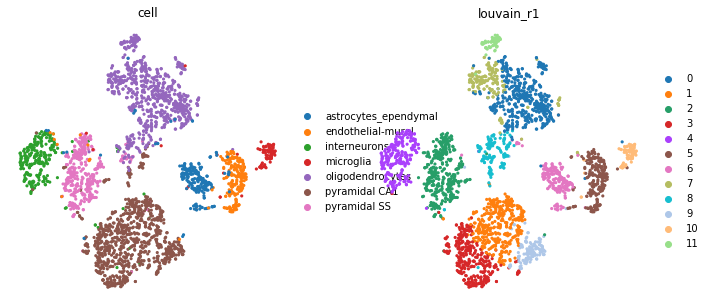

```python
sc.tl.louvain(ad, resolution=1, key_added = 'louvain_r1')
figsize(5,5)
sc.pl.tsne(ad, color=['cell','louvain_r1'], frameon=False)
```

## SCCAF assessment

- self-projectionを用いて、（人間の専門家による）クラスタリングのグローバルな精度をテストしています。
- 専門家によってアノテーションされた細胞タイプの識別は非常に明確で、精度は最大96%であることがわかりました。ほぼ完璧なクラスタリングです。

```
Mean CV accuracy: 0.9661
Accuracy on the training set: 0.9985
Accuracy on the hold-out set: 0.9486
```

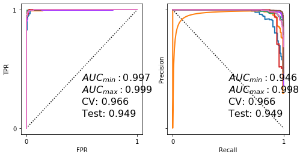

```python
rcParams['figure.figsize'] = 8,4

y_prob, y_pred, y_test, clf, cvsm, acc = SCCAF_assessment(ad.X, ad.obs['cell'], n=100)
aucs = plot_roc(y_prob, y_test, clf, cvsm=cvsm, acc=acc)
```

## SCCAF recover

- データのアノテーションが不明であり、最適なクラスタリング解を特定することを目的としているケース
- ここでは、まずオーバークラスタリング（細かすぎるクラスタリング）から始め、機械学習モデルで判別できないクラスタをマージしてクラスタリングを最適化してみます。(ここでは機械学習モデルとして線形モデルによるロジスティック回帰を使用します)。そして、アンダークラスタリングによって最適化を制約します。

```python
ad.obs['L1_Round0'] = ad.obs['louvain_r1']
```

```
R1norm_cutoff: 0.500000
R2norm_cutoff: 0.050000
Accuracy: 0.000000
======================
Round1 ...
Mean CV accuracy: 0.8925
Accuracy on the training set: 1.0000
Accuracy on the hold-out set: 0.9070
```

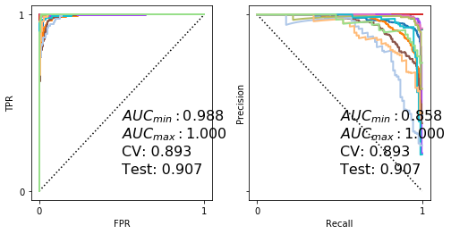

```
... storing 'L1_Round0_self-projection' as categorical
```

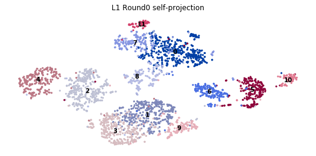

```
Accuracy on the training set: 1.0000
Accuracy on the hold-out set: 0.8980
Accuracy on the training set: 0.9990
Accuracy on the hold-out set: 0.8985
Accuracy on the training set: 0.9990
Accuracy on the hold-out set: 0.8875
Accuracy on the training set: 1.0000
Accuracy on the hold-out set: 0.9040
Max R1mat: 0.229730
Max R2mat: 0.015838
min_acc: 0.887500
```

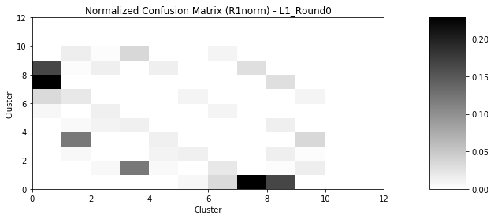

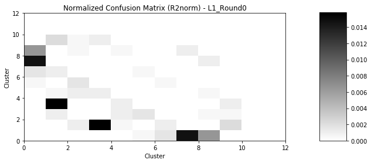

```
IGRAPH U-W- 12 0 --
+ attr: weight (e)
Converge SCCAF_optimize no. cluster!
m1: 0.229730
m2: 0.015838
Accuracy: 0.887500
R1norm_cutoff: 0.219730
R2norm_cutoff: 0.014838
Accuracy: 0.887500
======================
Round1 ...
Mean CV accuracy: 0.9134
Accuracy on the training set: 1.0000
Accuracy on the hold-out set: 0.9000
```

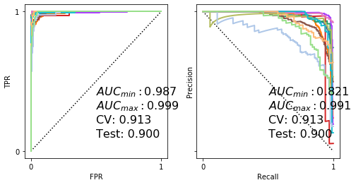

```
... storing 'L1_Round0_self-projection' as categorical
```

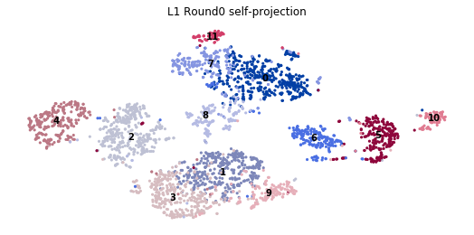

```
Accuracy on the training set: 1.0000
Accuracy on the hold-out set: 0.8985
Accuracy on the training set: 1.0000
Accuracy on the hold-out set: 0.8985
Accuracy on the training set: 1.0000
Accuracy on the hold-out set: 0.8925
Accuracy on the training set: 1.0000
Accuracy on the hold-out set: 0.8925
Max R1mat: 0.324324
Max R2mat: 0.019459
min_acc: 0.892500
```

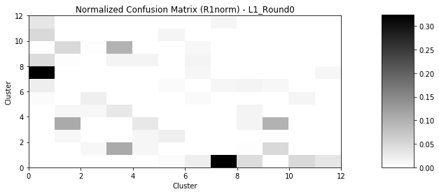

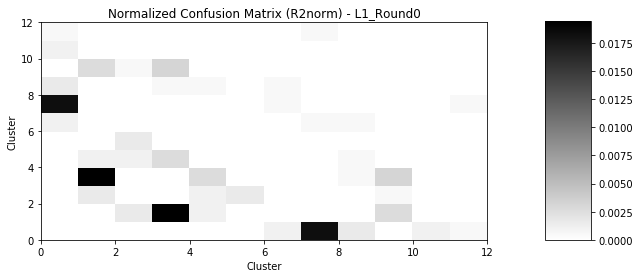

```
... storing 'L1_Round1' as categorical
```

```
IGRAPH U-W- 12 4 --
+ attr: weight (e)
+ edges:
0--7 1--3 1--3 0--7
```

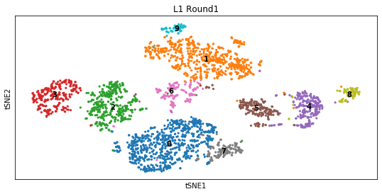

```
Round2 ...
Mean CV accuracy: 0.9423
Accuracy on the training set: 0.9988
Accuracy on the hold-out set: 0.9447
```

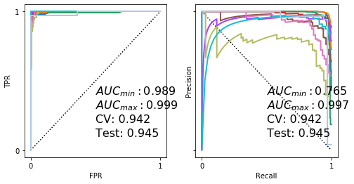

```
... storing 'L1_Round1_self-projection' as categorical
```

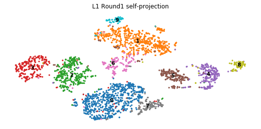

```
Accuracy on the training set: 1.0000
Accuracy on the hold-out set: 0.9498
Accuracy on the training set: 1.0000
Accuracy on the hold-out set: 0.9507
Accuracy on the training set: 1.0000
Accuracy on the hold-out set: 0.9516
Accuracy on the training set: 1.0000
Accuracy on the hold-out set: 0.9461
Max R1mat: 0.310345
Max R2mat: 0.010038
min_acc: 0.944749
```

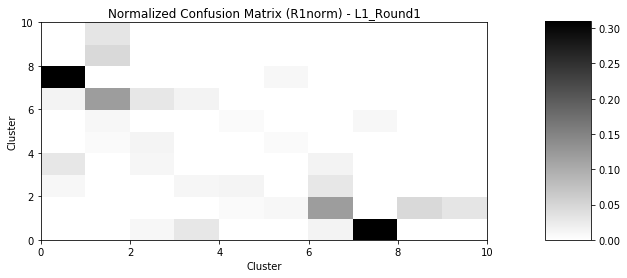

[4 more figures not shown]

```
Accuracy on the training set: 0.9987
Accuracy on the hold-out set: 0.9584
Accuracy on the training set: 1.0000
Accuracy on the hold-out set: 0.9619
Accuracy on the training set: 1.0000
Accuracy on the hold-out set: 0.9588
Accuracy on the training set: 0.9987
Accuracy on the hold-out set: 0.9553
Max R1mat: 0.173913
Max R2mat: 0.005505
Converge SCCAF_optimize min_acc!
m1: 0.173913
m2: 0.005505
Accuracy: 0.955270
```

```python
SCCAF_optimize_all(min_acc=0.953, ad=ad, basis ='tsne', c_iter=5) # use='pca'
```

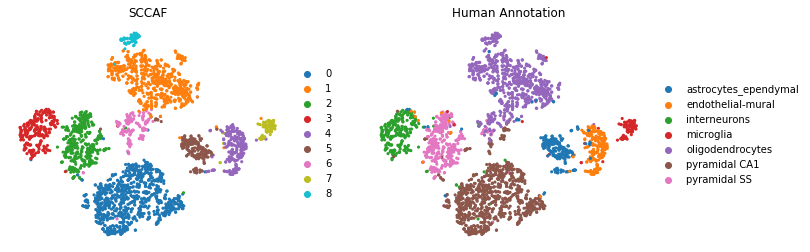

```python
rcParams['figure.figsize'] =5,4

sc.pl.tsne(ad, color=['L1_result','cell',],frameon=False, title=['SCCAF','Human Annotation'])
```

## SCCAF recover with constraints

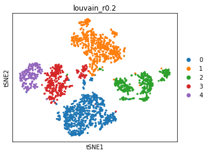

```python
sc.tl.louvain(ad, resolution=0.2, key_added='louvain_r0.2')
sc.pl.tsne(ad, color=['louvain_r0.2'])
```

```
R1norm_cutoff: 0.500000
R2norm_cutoff: 0.050000
Accuracy: 0.000000
======================
Round1 ...
Mean CV accuracy: 0.9114
Accuracy on the training set: 1.0000
Accuracy on the hold-out set: 0.8910
```

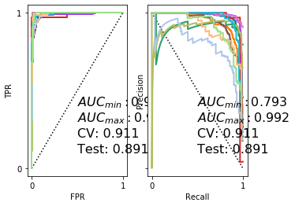

```
... storing 'L2_Round0_self-projection' as categorical
```

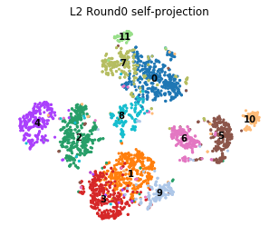

```
Accuracy on the training set: 1.0000
Accuracy on the hold-out set: 0.8935
Accuracy on the training set: 1.0000
Accuracy on the hold-out set: 0.8920
Max R1mat: 0.422535
Max R2mat: 0.021186
min_acc: 0.891000
```

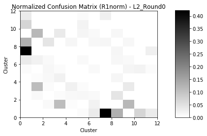

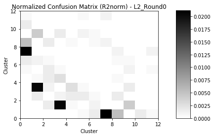

```
IGRAPH U-W- 12 0 --
+ attr: weight (e)
Converge SCCAF_optimize no. cluster!
m1: 0.422535
m2: 0.021186
Accuracy: 0.891000
R1norm_cutoff: 0.412535
R2norm_cutoff: 0.020186
Accuracy: 0.891000
======================
Round1 ...
Mean CV accuracy: 0.9005
Accuracy on the training set: 1.0000
Accuracy on the hold-out set: 0.9095
```

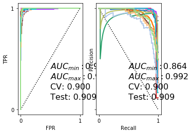

```
... storing 'L2_Round0_self-projection' as categorical
```

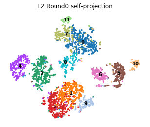

```
Accuracy on the training set: 1.0000
Accuracy on the hold-out set: 0.9070
Accuracy on the training set: 1.0000
Accuracy on the hold-out set: 0.8980
Max R1mat: 0.312500
Max R2mat: 0.018056
min_acc: 0.898000
```

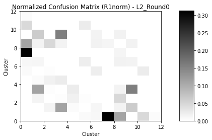

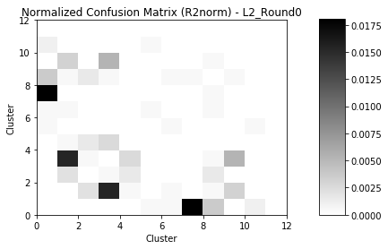

```
IGRAPH U-W- 12 0 --
+ attr: weight (e)
Converge SCCAF_optimize no. cluster!
m1: 0.312500
m2: 0.018056
Accuracy: 0.898000
R1norm_cutoff: 0.302500
R2norm_cutoff: 0.017056
Accuracy: 0.898000
======================
Round1 ...
Mean CV accuracy: 0.9025
Accuracy on the training set: 1.0000
Accuracy on the hold-out set: 0.9030
```

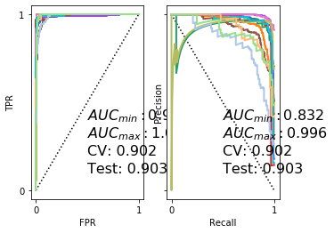

```
... storing 'L2_Round0_self-projection' as categorical
```

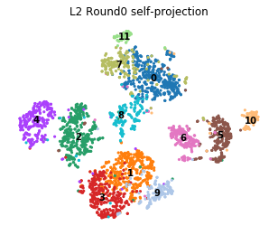

```
Accuracy on the training set: 1.0000
Accuracy on the hold-out set: 0.9090
Accuracy on the training set: 1.0000
Accuracy on the hold-out set: 0.8990
Max R1mat: 0.294872
Max R2mat: 0.022501
min_acc: 0.899000
```

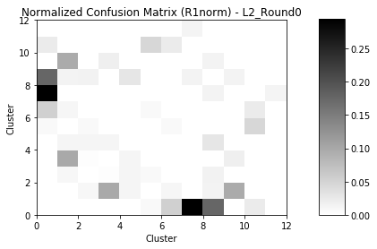

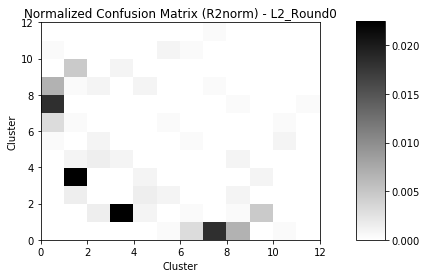

```
IGRAPH U-W- 12 0 --
+ attr: weight (e)
Converge SCCAF_optimize no. cluster!
m1: 0.294872
m2: 0.022501
Accuracy: 0.899000
R1norm_cutoff: 0.284872
R2norm_cutoff: 0.021501
Accuracy: 0.899000
======================
Round1 ...
Mean CV accuracy: 0.8965
Accuracy on the training set: 1.0000
Accuracy on the hold-out set: 0.9040
```

[4 more figures not shown]

```
IGRAPH U-W- 12 0 --
+ attr: weight (e)
Converge SCCAF_optimize no. cluster!
m1: 0.280000
m2: 0.024313
Accuracy: 0.897000
converged SCCAF_all!
```

```python
ad.obs['L2_Round0'] = ad.obs['L1_Round0']
SCCAF_optimize_all(min_acc=0.955, ad=ad, basis ='tsne',low_res='louvain_r0.2', prefix='L2') # use='pca'
```

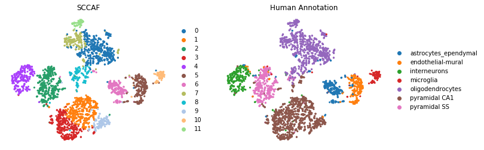

```python
sc.pl.tsne(ad, color=['L2_result','cell',], frameon=False, title=['SCCAF','Human Annotation'])
```

## UMAPに変えてみる

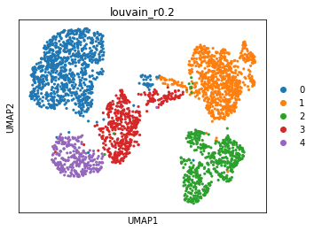

```python
sc.tl.louvain(ad, resolution=0.2, key_added='louvain_r0.2')
sc.pl.umap(ad, color=['louvain_r0.2'])
```